# PRAC 2 Tipología y ciclo de vida de los datos

```r
library(ggplot2)
library(dplyr)
library(tidyr)
library(nortest)
```

1. descripción del dataset.

El conjunto de datos de análisis de ha obtenido en Kaggle [1] y está constituido por 12 caracteristicas (columnas) que presentan 891 pasajeros (registros). El conjunto de datos contiene los siguientes campos:

```
PassengerId: Identificador numérico de cada pasajero

Survived: Indica si el pasajero sobrevivió (1) o no (0) al naufragio

Pclass: Clase en la que viajaba (1ra, 2da o 3ra)

Name: Nombre

Sex: Sexo

Age: Edad

SibSp: Número de hermanos o esposos a bordo

Parch: Número de padres o hijos a bordo

Ticket: Referencia del Ticket

Fare: Tarifa

Cabin: Cabina

embarked: Puerto de embarque
```

A partir de estos datos se plantea la problematica de determinar que variables influyen más sobre la supervivencia al naufragio de un pasajero

2. Integración y selección de los datos de interés a analizar.

Hay campos que claramente no influyen en la supervivencia de un pasajero y por lo tanto podemos desestimar a priori. Estos son: Ticket, Fare y embarked, puesto que ni la referencia del ticket, ni su precio, ni el puerto donde embarco el pasajero influyen en el análisis por razones obvias; Cabin, porque aunque quizá la localización de la cabina pueda influir en la evacuación, ni tenemos la localización de las cabinas ni podemos asumir que los pasajeros se encontraban en ellas. Aunque el numero de parientes pueda parecer irrelevante lo dejaremos para analizar si los lazos con otros pasajeros pudieron influir en la supervivencia de cada uno. Por ultimo aunque el nombre claramente no influya lo mantenemos en el dataset para futuras visualizaciones.

```r
# Lectura de datos
titanic <- read.csv('titanic.csv',stringsAsFactors = FALSE)
```

```r
# Se eliminan los campos Ticket, Fare. Embarked. Cabin
titanic <- select(titanic, -Ticket, - Fare, -Embarked, -Cabin)
head(titanic)
```

|  | PassengerId | Survived | Pclass | Name | Sex | Age | SibSp | Parch |
| --- | --- | --- | --- | --- | --- | --- | --- | --- |
| 1 | 1 | 0 | 3 | Braund, Mr. Owen Harris | male | 22 | 1 | 0 |
| 2 | 2 | 1 | 1 | Cumings, Mrs. John Bradley (Florence Briggs Thayer) | female | 38 | 1 | 0 |
| 3 | 3 | 1 | 3 | Heikkinen, Miss. Laina | female | 26 | 0 | 0 |
| 4 | 4 | 1 | 1 | Futrelle, Mrs. Jacques Heath (Lily May Peel) | female | 35 | 1 | 0 |
| 5 | 5 | 0 | 3 | Allen, Mr. William Henry | male | 35 | 0 | 0 |
| 6 | 6 | 0 | 3 | Moran, Mr. James | male | NA | 0 | 0 |

3. Limpieza de datos

```r
# Tipo de dato asignado a cada campo
sapply(titanic, function(x) class(x))
```

```
## PassengerId    Survived      Pclass        Name         Sex         Age
##   "integer"   "integer"   "integer" "character" "character"   "numeric"
##       SibSp       Parch
##   "integer"   "integer"
```

Para los test es necesario guardar las variables Sex, Pclass y Survived en variables numéricas antes de pasarlas a categorias.

```r
titanic$SexNum <- ifelse(titanic$Sex == "male", 1, 0)
titanic$SurvivedNum <- titanic$Survived
titanic$PclassNum <- titanic$Pclass

titanic$Survived <- factor(titanic$Survived)
titanic$Pclass <- factor(titanic$Pclass)
titanic$Sex <- factor(titanic$Sex)
```

3.1 Ceros y elementos vacios

```r
# Números de valores desconocidos por campo
sapply(titanic, function(x) sum(is.na(x)))
```

```
## PassengerId    Survived      Pclass        Name         Sex         Age
##           0           0           0           0           0         177
##       SibSp       Parch      SexNum SurvivedNum   PclassNum
##           0           0           0           0           0
```

https://www.kaggle.com/allohvk/titanic-missing-age-imputation-tutorial-advanced

En Age encontramos un alto numero de valores vacios. Para obtener un valor adecuado nos basamos el resto de paswajeros similares para deducir una edad aproximada. Sin embargo, el resto de campos no ayudan a determinar la edad del pasajero, no estan muy relacionados. Se puede dividir los datos en grupos para obtener la edad media de los mismos y así deducir los valores vacios. Por ejemplo dividir entre hombres y mujeres obteniendo la media e introducioendola en los valores vacíos de sus respectivos grupos. Pero es preferivle obtener una división que se relacione mejor con la edad. En base a otros trabajos publicados con este dataset [2] se ha observado que en el nombre hay un indicativo para referirse a los pasajeros (Mr, Mrs, Lady, Capt…) que se ajusta mejor a la edad. Pocos pasajeros adultos no estarán casados, o por ejemplo la edad media de “Master” es 5 años. Por lo tanto se obtienen los diferentes apelativos y se obtiene la edad media de cada uno para introducirla finalmente en los valores faltantes de cada grupo

```r
titulos <- unique(separate(separate(titanic,"Name", c("A", "B"),sep=","), "B", "titulos", sep="\\. ")[,"titulos"])
titulos
```

```
##  [1] " Mr"           " Mrs"          " Miss"         " Master"
##  [5] " Don"          " Rev"          " Dr"           " Mme"
##  [9] " Ms"           " Major"        " Lady"         " Sir"
## [13] " Mlle"         " Col"          " Capt"         " the Countess"
## [17] " Jonkheer"
```

```r
for (t in titulos){
  p<-paste(".*",t,".*", sep="")
  titanic[grepl(p, titanic$Name) & is.na(titanic$Age), "Age"]<-mean(titanic[grepl(p, titanic$Name) & !is.na(titanic$Age), "Age"])
}
```

3.2 Identificación y tratamiento de valores extremos

Para los valores categóricos se comprueba directamente si alguno de los valores no se encuentra dentro de los esperados:

```
Survived: 0 1
Pclass: 1 2 3
Sex: male female
```

```r
titanic[(titanic$Survived != 1 & titanic$Survived != 0),"Survived"]
```

```
## factor(0)
## Levels: 0 1
```

```r
titanic[(titanic$Pclass != 1 & titanic$Pclass != 2 & titanic$Pclass != 3), "Pclass"]
```

```
## factor(0)
## Levels: 1 2 3
```

```r
titanic[(titanic$Sex != "male" & titanic$Sex != "female"),"Sex"]
```

```
## factor(0)
## Levels: female male
```

Para el resto buscamos outliers mediante la representcion de los datos en diagramas de caja.

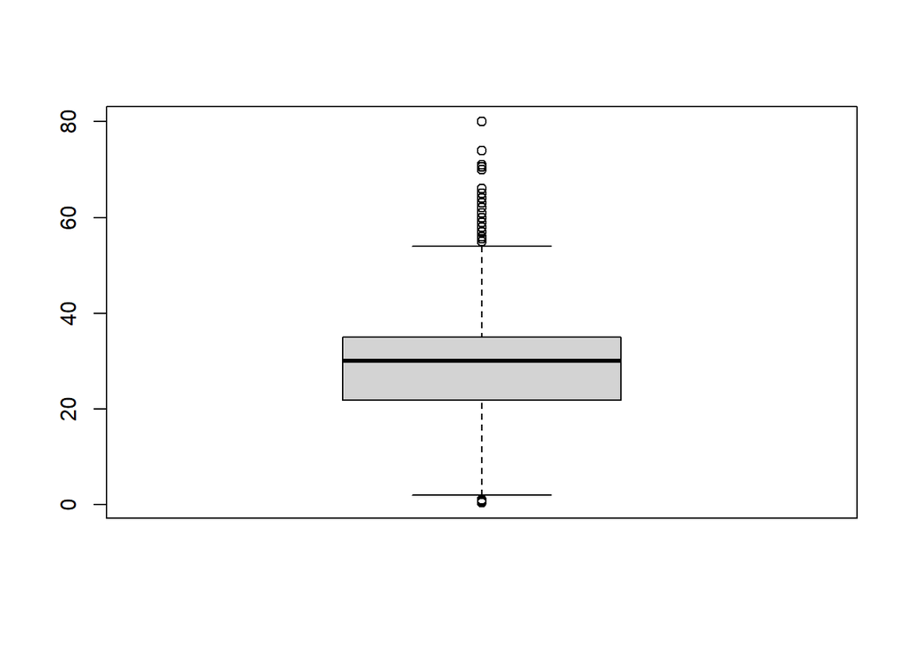

```r
boxplot(titanic$Age)
```

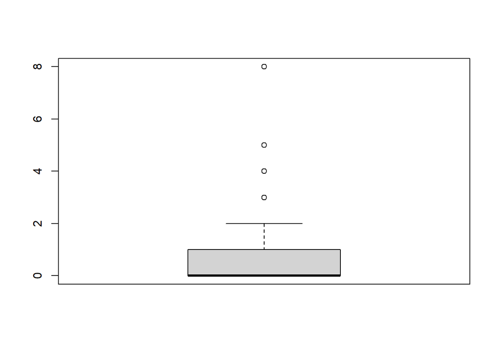

```r
boxplot(titanic$SibSp)
```

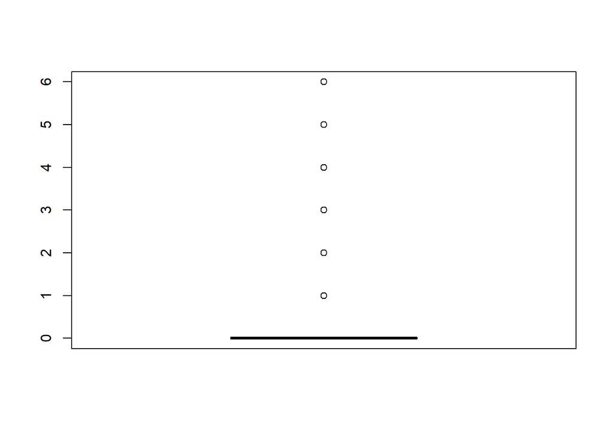

```r
boxplot(titanic$Parch)
```

A pesar de que se obtienen valores extremos ningun valor resulta imposible. Por ejemplo una familia puede tener 6 hijos pero no podría tener -1. Como no aparecen valores negativos o exageradamente altos se mantienen todos los registros.

4. Análisis de datos

4.1 Selección de datos y planificación de los analisis a aplicar

Se agrupan los datos con el objetivo de hacer analisis mas minuciosos en el futuro.

```r
# Agrupación por clase
titanic.primera <- titanic[titanic$Pclass == 1, ]
titanic.segunda <- titanic[titanic$Pclass == 2, ]
titanic.tercera <- titanic[titanic$Pclass == 3, ]

# Agrupación por Sexo
titanic.male <- titanic[titanic$Sex == "male", ]
titanic.female <- titanic[titanic$Sex == "female", ]

# Agrupación por Edad

titanic.menores <- titanic[titanic$PAge < 18, ]
titanic.jovenes <- titanic[titanic$PAge >= 18 & titanic$Age < 36, ]
titanic.adultos <- titanic[titanic$PAge >= 36 & titanic$Age < 65, ]
titanic.mayores <- titanic[titanic$PAge >= 65, ]

# Agrupación por parientes

titanic.conParientes <- titanic[titanic$SibSp > 0 | titanic$Parch > 0, ]
titanic.sinParientes <- titanic[titanic$SibSp == 0 & titanic$Parch == 0, ]
```

4.2 Comprobación de la normalidad y homogeneidad de la varianza

Para la comprobación de que los valores que toman nuestras variables cuantitativas provienen de una población distribuida normalmente, utilizaremos la prueba de normalidad de AndersonDarling. Así, se comprueba que para que cada prueba se obtiene un p-valor superior al nivel de significación prefijado α = 0, 05. Si esto se cumple, entonces se considera que variable en cuestión sigue una distribución normal.

```r
alpha = 0.05
col.names = colnames(titanic)
for (i in 1:ncol(titanic)) {
  if (i == 1) cat("Variables que no siguen una distribución normal:\n")
    if (is.integer(titanic[,i]) | is.numeric(titanic[,i])) {
      p_val = ad.test(titanic[,i])$p.value
      if (p_val < alpha) {
        cat(col.names[i])

        if (i < ncol(titanic) - 1) cat(", ")
        if (i %% 3 == 0) cat("\n")
      }
    }
  }
```

```
## Variables que no siguen una distribución normal:
## PassengerId, Age,
## SibSp, Parch, SexNum,
## SurvivedNumPclassNum
```

Ninguna variable sigue una distribución normal sin embargo, por el teorema central del limite, como tenemos más de 30 muestras podemos asumir normalidad.

4.3 Aplicación de pruebas estaisticas

Seguidamente, pasamos a estudiar la homogeneidad de varianzas mediante la aplicación de un test de Fligner-Killeen. En este caso, estudiaremos esta homogeneidad en cuanto a los grupos conformados por los hombres frente a las mujeres. En el siguiente test, la hipótesis nula consiste en que ambas varianzas son iguales.

```r
fligner.test(SurvivedNum ~ SexNum, data = titanic)
```

```
##
##  Fligner-Killeen test of homogeneity of variances
##
## data:  SurvivedNum by SexNum
## Fligner-Killeen:med chi-squared = 5.7729, df = 1, p-value = 0.01627
```

A continuación realizamos una regresión logistica con todas las variables.

```r
# Training model
regresionLogistica <- glm(Survived ~ Sex + Pclass + Age + SibSp + Parch,
                      data = titanic,
                      family = "binomial")
summary(regresionLogistica)
```

```
##
## Call:
## glm(formula = Survived ~ Sex + Pclass + Age + SibSp + Parch,
##     family = "binomial", data = titanic)
##
## Deviance Residuals:
##     Min       1Q   Median       3Q      Max
## -2.7042  -0.5978  -0.4185   0.6153   2.5126
##
## Coefficients:
##              Estimate Std. Error z value Pr(>|z|)
## (Intercept)  4.237082   0.408504  10.372  < 2e-16 ***
## Sexmale     -2.722799   0.198499 -13.717  < 2e-16 ***
## Pclass2     -1.242752   0.262993  -4.725 2.30e-06 ***
## Pclass3     -2.435650   0.247540  -9.839  < 2e-16 ***
## Age         -0.044376   0.007877  -5.634 1.76e-08 ***
## SibSp       -0.361015   0.108809  -3.318 0.000907 ***
## Parch       -0.078596   0.115464  -0.681 0.496060
## ---
## Signif. codes:  0 '***' 0.001 '**' 0.01 '*' 0.05 '.' 0.1 ' ' 1
##
## (Dispersion parameter for binomial family taken to be 1)
##
##     Null deviance: 1186.7  on 890  degrees of freedom
## Residual deviance:  784.4  on 884  degrees of freedom
## AIC: 798.4
##
## Number of Fisher Scoring iterations: 5
```

Vemos que todos los campos influyen excepto Parch.

A continucaión vamos a comprobar la precisión del modelo.

```r
predict_reg <- predict(regresionLogistica,
                       titanic, type = "response")
predict_reg <- ifelse(predict_reg >0.5, 1, 0)

count(titanic[titanic$Survived == predict_reg,])/count(titanic)*100
```

| n |
| --- |
| 79.46128 |

Se obtiene una precisión del 79,46%.

A continuación se va a hacer un analisis de correlación de las diferentes variables. Como se ha explicado antes se asume normalidad por el teorema central del limte.

```r
cor.test(titanic$SurvivedNum, titanic$SexNum)
```

```
##
##  Pearson's product-moment correlation
##
## data:  titanic$SurvivedNum and titanic$SexNum
## t = -19.298, df = 889, p-value < 2.2e-16
## alternative hypothesis: true correlation is not equal to 0
## 95 percent confidence interval:
##  -0.5880439 -0.4953510
## sample estimates:
##        cor
## -0.5433514
```

```r
cor.test(titanic$SurvivedNum, titanic$PclassNum)
```

```
##
##  Pearson's product-moment correlation
##
## data:  titanic$SurvivedNum and titanic$PclassNum
## t = -10.725, df = 889, p-value < 2.2e-16
## alternative hypothesis: true correlation is not equal to 0
## 95 percent confidence interval:
##  -0.3953692 -0.2790061
## sample estimates:
##       cor
## -0.338481
```

```r
cor.test(titanic$SurvivedNum, titanic$Age)
```

```
##
##  Pearson's product-moment correlation
##
## data:  titanic$SurvivedNum and titanic$Age
## t = -2.9004, df = 889, p-value = 0.003819
## alternative hypothesis: true correlation is not equal to 0
## 95 percent confidence interval:
##  -0.16146903 -0.03134025
## sample estimates:
##         cor
## -0.09681837
```

```r
cor.test(titanic$SurvivedNum, titanic$SibSp)
```

```
##
##  Pearson's product-moment correlation
##
## data:  titanic$SurvivedNum and titanic$SibSp
## t = -1.0538, df = 889, p-value = 0.2922
## alternative hypothesis: true correlation is not equal to 0
## 95 percent confidence interval:
##  -0.10076614  0.03042549
## sample estimates:
##        cor
## -0.0353225
```

```r
# Training model
regresionLogistica <- glm(Survived ~ Parch,
                      data = titanic,
                      family = "binomial")

predict_reg <- predict(regresionLogistica,
                       titanic, type = "response")
predict_reg <- ifelse(predict_reg >0.5, 1, 0)


count(titanic[titanic$Survived == predict_reg,])/count(titanic)*100
```

| n |
| --- |
| 60.83053 |

5. Resolución del problema

Observamos como en un mismo gráfico de frecuencias las variables que más afectan Sex y Pclass.

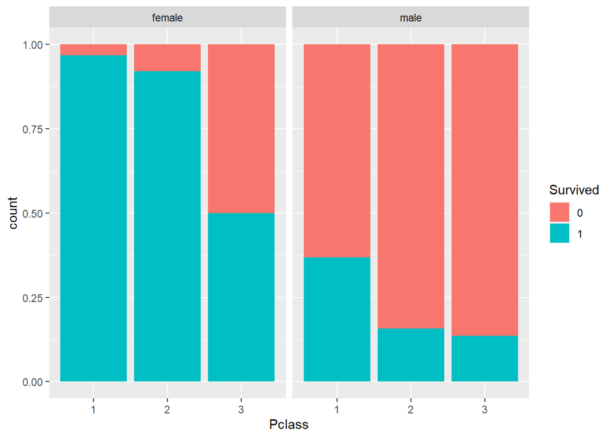

```r
# Ahora, podemos dividir el gráfico de Embarked por Pclass:
ggplot(data = titanic,aes(x=Pclass,fill=Survived))+geom_bar(position="fill")+facet_wrap(~Sex)
```

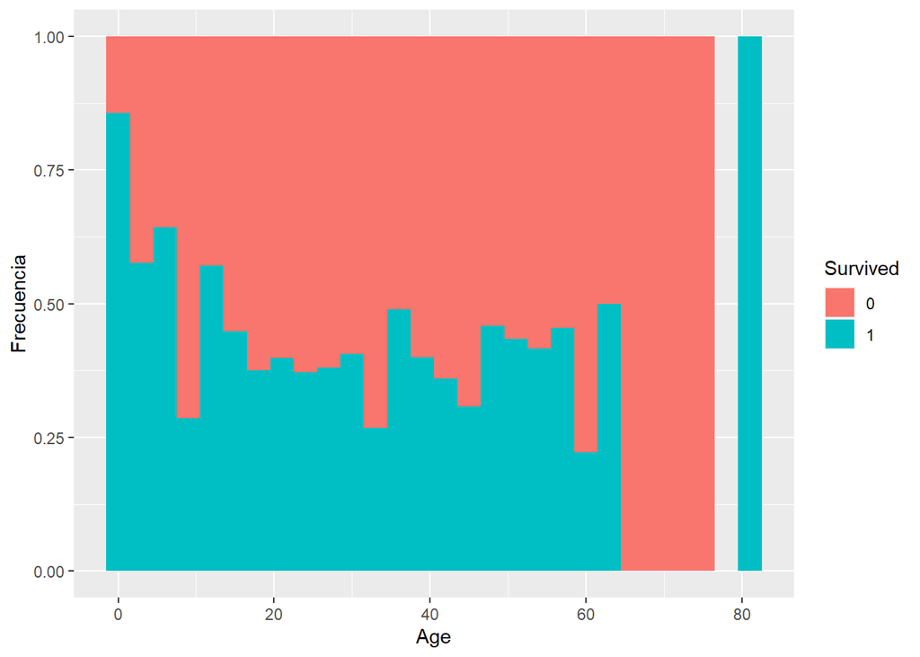

```r
# Survival como función de age:
ggplot(data = titanic[!is.na(titanic$Age),],aes(x=Age,fill=Survived))+geom_histogram(binwidth = 3,position="fill")+ylab("Frecuencia")
```

Se represnta también Patch

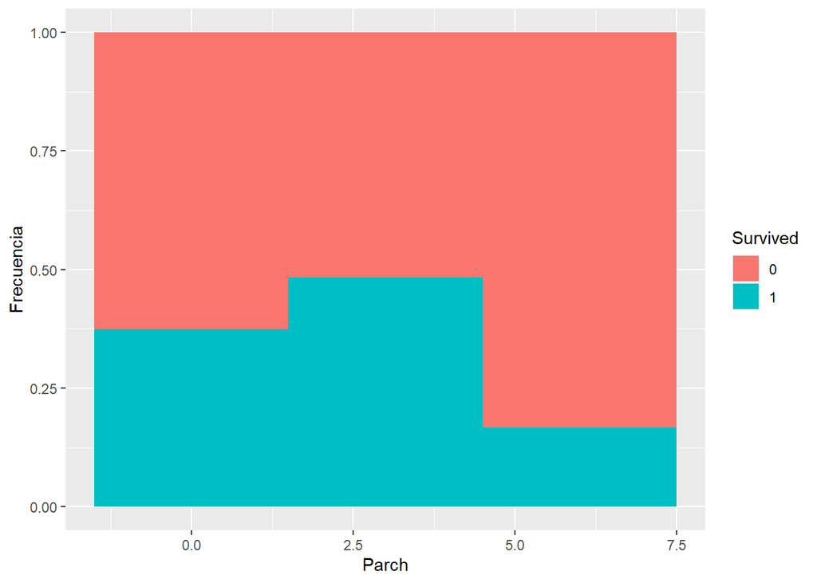

```r
ggplot(data = titanic[!is.na(titanic$Parch),],aes(x=Parch,fill=Survived))+geom_histogram(binwidth = 3,position="fill")+ylab("Frecuencia")
```

A pesar de que en el analisis previo nos indicaba que este campo no influia vemos que a partir de 4 si parece influir en la supervivencia. Sin embargo, si tenemos en cuenta el numero de registros se observa que este resultado atipico se debe a que apenas hay pasajeros con estos valores.

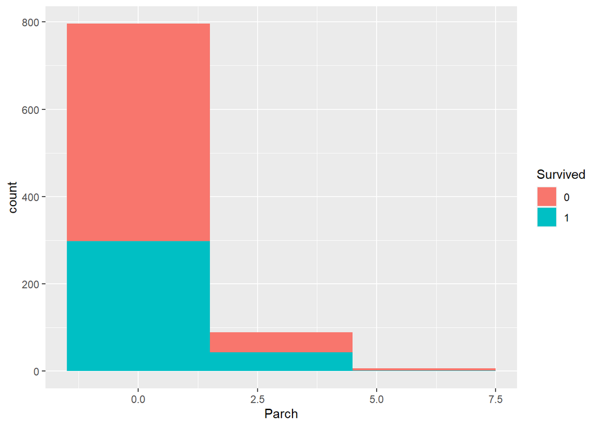

```r
ggplot(data = titanic[!(is.na(titanic$Parch)),],aes(x=Parch,fill=Survived))+geom_histogram(binwidth =3)
```

6 Resolución del problema

Se observa claramente que las variables que más influyeron en la supervivencia de los pasajeros fueron la clase, puesto que se priorizó a los pasajeros de clase superior y el sexo, puesto que se priorizó a las mujeres.